# World Happiness Case Study

Jace Wilderman

2025-07-06

## Install and load ‘tidyverse’ packages (optional)

If `tidyverse` has not already been installed and loaded, run the code segment below to ensure that there will not be issues when calling functions included with the `tidyverse` package.

## Importing Data

Run the code below to load the 2019 World Happiness Report `2019.csv` to a data frame. The rename function is also used to change the names of the columns.

## Plotting correlations

With this first chart, we plot how Economy correlates to Score to see if there are any trends that can be defined. We include a trendline to highlight the trend we can see the plots following.

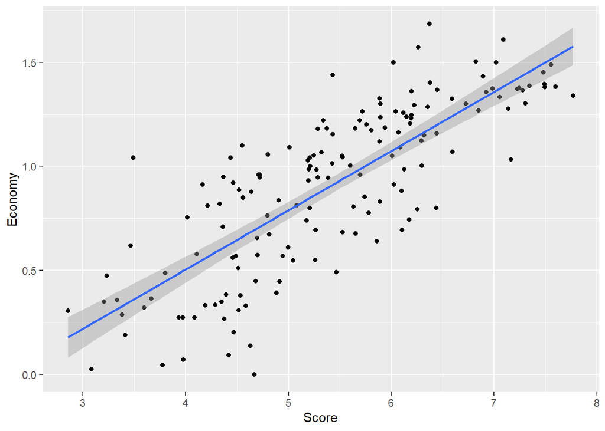

With this second chart, we view the correlation between Social_support and Score.

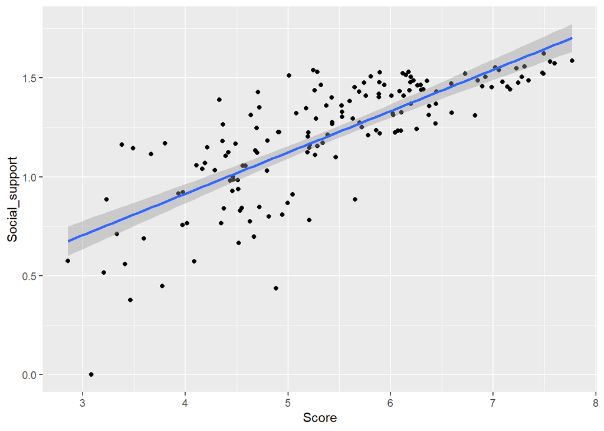

This third chart shows the correlation that Life_expectancy has on Score.

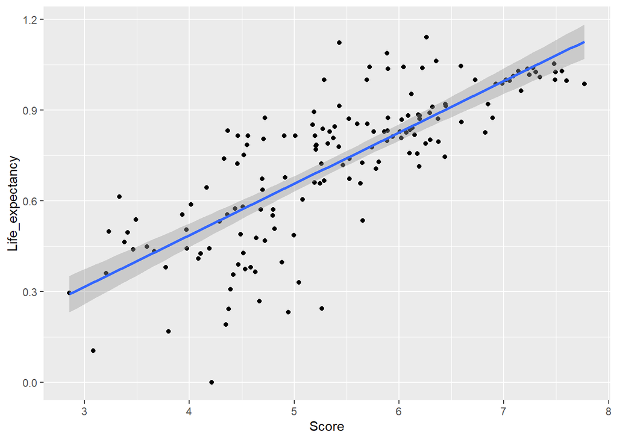

With each of these charts, we can see that each of these factors play some part in the happiness score of a country.

## Importing data for 2018 World Happiness Report

To gain a better view on how the changes in these factors affect happiness scores.

```
## spc_tbl_ [156 × 9] (S3: spec_tbl_df/tbl_df/tbl/data.frame)
##  $ Happiness_Rank           : num [1:156] 1 2 3 4 5 6 7 8 9 10 ...
##  $ Country                  : chr [1:156] "Finland" "Denmark" "Norway" "Iceland" ...
##  $ Score                    : num [1:156] 7.77 7.6 7.55 7.49 7.49 ...
##  $ Economy                  : num [1:156] 1.34 1.38 1.49 1.38 1.4 ...
##  $ Social_support           : num [1:156] 1.59 1.57 1.58 1.62 1.52 ...
##  $ Life_expectancy          : num [1:156] 0.986 0.996 1.028 1.026 0.999 ...
##  $ Freedom_of_choice        : num [1:156] 0.596 0.592 0.603 0.591 0.557 0.572 0.574 0.585 0.584 0.532 ...
##  $ Generosity               : num [1:156] 0.153 0.252 0.271 0.354 0.322 0.263 0.267 0.33 0.285 0.244 ...
##  $ Perceptions_of_corruption: num [1:156] 0.393 0.41 0.341 0.118 0.298 0.343 0.373 0.38 0.308 0.226 ...
##  - attr(*, "spec")=
##   .. cols(
##   ..   `Overall rank` = col_double(),
##   ..   `Country or region` = col_character(),
##   ..   Score = col_double(),
##   ..   `GDP per capita` = col_double(),
##   ..   `Social support` = col_double(),
##   ..   `Healthy life expectancy` = col_double(),
##   ..   `Freedom to make life choices` = col_double(),
##   ..   Generosity = col_double(),
##   ..   `Perceptions of corruption` = col_double()
##   .. )
##  - attr(*, "problems")=<externalptr>
```

```
## spc_tbl_ [156 × 9] (S3: spec_tbl_df/tbl_df/tbl/data.frame)
##  $ Overall rank                : num [1:156] 1 2 3 4 5 6 7 8 9 10 ...
##  $ Country or region           : chr [1:156] "Finland" "Norway" "Denmark" "Iceland" ...
##  $ Score                       : num [1:156] 7.63 7.59 7.55 7.5 7.49 ...
##  $ GDP per capita              : num [1:156] 1.3 1.46 1.35 1.34 1.42 ...
##  $ Social support              : num [1:156] 1.59 1.58 1.59 1.64 1.55 ...
##  $ Healthy life expectancy     : num [1:156] 0.874 0.861 0.868 0.914 0.927 0.878 0.896 0.876 0.913 0.91 ...
##  $ Freedom to make life choices: num [1:156] 0.681 0.686 0.683 0.677 0.66 0.638 0.653 0.669 0.659 0.647 ...
##  $ Generosity                  : num [1:156] 0.202 0.286 0.284 0.353 0.256 0.333 0.321 0.365 0.285 0.361 ...
##  $ Perceptions of corruption   : chr [1:156] "0.393" "0.340" "0.408" "0.138" ...
##  - attr(*, "spec")=
##   .. cols(
##   ..   `Overall rank` = col_double(),
##   ..   `Country or region` = col_character(),
##   ..   Score = col_double(),
##   ..   `GDP per capita` = col_double(),
##   ..   `Social support` = col_double(),
##   ..   `Healthy life expectancy` = col_double(),
##   ..   `Freedom to make life choices` = col_double(),
##   ..   Generosity = col_double(),
##   ..   `Perceptions of corruption` = col_character()
##   .. )
##  - attr(*, "problems")=<externalptr>
```

There are some differences in data structure and column names, so we will address those before we use the data frame. After running this code segment, we will get a warning, but this is expected and will not cause issues.

```
## Warning: NAs introduced by coercion
```

## Combining data and calculating score changes

Now we will combine the data from both `happiness_2018` and `happiness_2018` by Country.

With this combined data frame will calcuate the score differences between the year and save them to a new data frame.

## Conclusions based on score changes

We will now plot the new data changes to see if we can identify correlations.

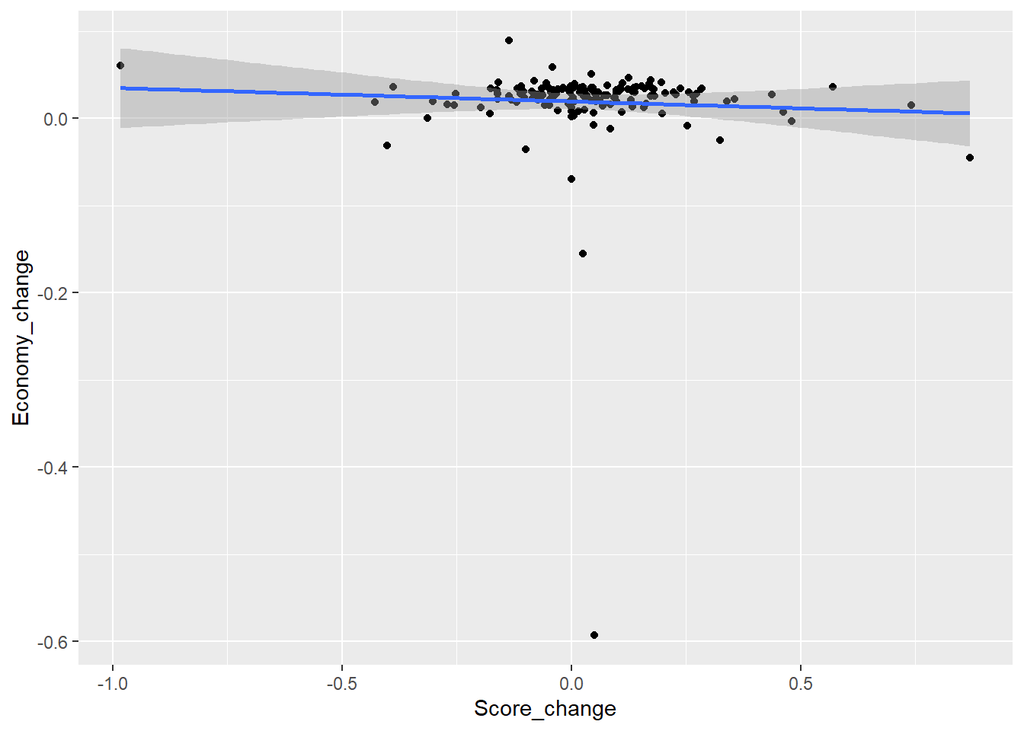

```r
ggplot(data = happiness_change, mapping = aes(x = Score_change, y = Economy_change)) +
  geom_point() +
  geom_smooth(method = "lm")
```

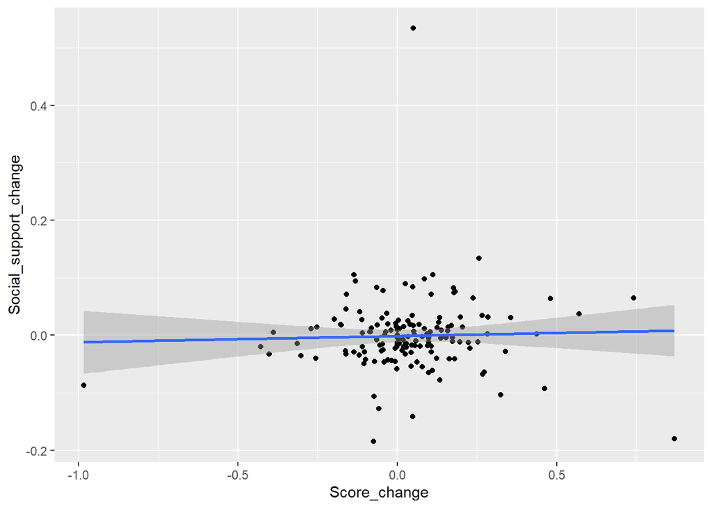

```r
ggplot(data = happiness_change, mapping = aes(x = Score_change, y = Social_support_change)) +
  geom_point() +
  geom_smooth(method = "lm")
```

When looking at these charts we can notice that there is not as strong of a correlation between each factor and the change in score.

## Conclusions

1. Each factor does influence the score, but if we want to see a greater increase in happiness score, we must work to improve each factor not just focusing on one.
2. Efforts can be more efficient if directed towards areas that the country has scored lower in.
3. Just because a country has a lower happiness score, it does not mean that all of their scores are lower. It might mean that a few of these areas might need to be improved on.